# JSC370_Project_Midterm

## 1. Introduction

- This dataset, the Neighbourhood Crime Rates dataset, is from the City of Toronto Open Data Portal. The portal is the City’s official open data source (https://www.toronto.ca/city-government/data-research-maps/open-data/), and this dataset contains crime data by neighbourhood. In the data table, each row represents one Toronto neighbourhood, and the columns describe different neighbourhood-level crime measures. ‘This dataset includes the Crime Data by Neighbourhood. Counts are available for Assault, Auto Theft, Break and Enter, Robbery, Theft Over, Homicide and Shooting & Firearm Discharges. Data also includes the crime rate per 100,000 population calculated using the population estimates provided by Environics Analytics.’ quoted from https://open.toronto.ca/dataset/neighbourhood-crime-rates/, the dataset description page.
- Questions to be answered in this project (WIP):
  1. How much do recorded crime rates vary across Toronto neighbourhoods?
  2. Which offence categories show the greatest neighbourhood-to-neighbourhood variation?
  3. Do neighbourhoods with high values in one offence category also tend to have high values in others?
  4. Do crime counts and crime rates tell the same story across neighbourhoods?
  5. etc. (pending)

## 2. Data Acquisition and library imports

```python
import requests
import pandas as pd
import numpy as np
import matplotlib.pyplot as plt
import seaborn as sns
import re
from itertools import combinations
from scipy.stats import spearmanr
from statsmodels.stats.multitest import multipletests
from itertools import combinations
from scipy.stats import pearsonr
```

```python
base_url = "https://ckan0.cf.opendata.inter.prod-toronto.ca"

# Developer code given by dataset website
package = requests.get(
    base_url + "/api/3/action/package_show",
    params={"id": "neighbourhood-crime-rates"}
).json()

resource_id = None
for resource in package["result"]["resources"]:
    if resource["datastore_active"]:
        resource_id = resource["id"]
        print("Using resource:", resource["name"])
        print("Resource ID:", resource_id)
        break

if resource_id is None:
    raise ValueError("No datastore_active resource found.")

dump_url = f"{base_url}/datastore/dump/{resource_id}"
df = pd.read_csv(dump_url)

# print(df.head())
# print(df.shape)
print(df.columns.tolist())
```

```
Using resource: neighbourhood-crime-rates
Resource ID: d4160604-9f3e-4589-8821-9fd70fa350b3
['_id', 'AREA_NAME', 'HOOD_ID', 'ASSAULT_2014', 'ASSAULT_2015', 'ASSAULT_2016', 'ASSAULT_2017', 'ASSAULT_2018', 'ASSAULT_2019', 'ASSAULT_2020', 'ASSAULT_2021', 'ASSAULT_2022', 'ASSAULT_2023', 'ASSAULT_2024', 'ASSAULT_2025', 'ASSAULT_RATE_2014', 'ASSAULT_RATE_2015', 'ASSAULT_RATE_2016', 'ASSAULT_RATE…
```

- The dataset doesnt contain a metadata file for detailed data description. However, the column names are mostly self-explanatory.

## 3. EDA

```python
# Basic inspection
print("Shape:", df.shape)

print("\nData types:")
print(df.dtypes)
```

```
Shape: (158, 221)

Data types:
_id                      int64
AREA_NAME               object
HOOD_ID                  int64
ASSAULT_2014             int64
ASSAULT_2015             int64
                        ...
THEFTOVER_RATE_2023    float64
THEFTOVER_RATE_2024    float64
THEFTOVER_RATE_2025    float64
POPULATION_2025          int64
geometry                object
Length: 221, dtype: object
```

```python
print("\nMissing values in each column: (omitted for clean report)")
missing = df.isna().sum()
missing = missing[missing > 0]

# print(missing.to_string())
```

```
Missing values in each column: (omitted for clean report)
```

```python
missing_threshold = 50

col_map = {col: col.lower() for col in df.columns}

crime_types = sorted({
    re.match(r"^(.*)_rate_\d{4}$", lower_col).group(1)
    for lower_col in col_map.values()
    if re.match(r"^(.*)_rate_\d{4}$", lower_col)
})

crime_cols = {}

for crime in crime_types:
    pattern = re.compile(rf"^{re.escape(crime)}(_rate)?_\d{{4}}$")
    matched_original_cols = [
        orig_col
        for orig_col, lower_col in col_map.items()
        if pattern.match(lower_col)
    ]
    crime_cols[crime] = matched_original_cols

crime_summary = []
crime_types_to_drop = []

for crime, cols in crime_cols.items():
    if not cols:
        continue

    missing_counts = df[cols].isna().sum()
    max_missing = int(missing_counts.max())
    worst_col = missing_counts.idxmax()

    crime_summary.append({
        "crime_type": crime,
        "max_missing_in_any_column": max_missing,
        "worst_column": worst_col,
        "drop_this_crime": max_missing >= missing_threshold
    })

    if max_missing >= missing_threshold:
        crime_types_to_drop.append(crime)

crime_summary = pd.DataFrame(crime_summary)

if not crime_summary.empty:
    crime_summary = crime_summary.sort_values(
        "max_missing_in_any_column", ascending=False
    )

print("\nCrime summary:")
print(crime_summary.to_string(index=False))

cols_to_drop = sorted([
    col
    for crime in crime_types_to_drop
    for col in crime_cols[crime]
])

print("\nCrime types to drop:")
print(crime_types_to_drop)

print("\nColumns to drop:")
print(cols_to_drop)

df = df.drop(columns=cols_to_drop).copy()

print("\nShape before dropping remaining null rows:", df.shape)
df_clean = df.dropna().reset_index(drop=True)
print("Shape after dropping remaining null rows:", df.shape)
```

```
Crime summary:
 crime_type  max_missing_in_any_column     worst_column  drop_this_crime
   homicide                        121    HOMICIDE_2025             True
   shooting                         78    SHOOTING_2014             True
  biketheft                         11   BIKETHEFT_2025            False
  theftover                          9   THEFTOVER_2016            False
    robbery                          2     ROBBERY_2022            False
  autotheft                          1   AUTOTHEFT_2017            False
    assault                          0     ASSAULT_2014            False
 breakenter                          0  BREAKENTER_2014            False
theftfrommv                          0 THEFTFROMMV_2014            False

Crime types to drop:
['homicide', 'shooting']

Columns to drop:
['HOMICIDE_2014', 'HOMICIDE_2015', 'HOMICIDE_2016', 'HOMICIDE_2017', 'HOMICIDE_2018', 'HOMICIDE_2019', 'HOMICIDE_2020', 'HOMICIDE_2021', 'HOMICIDE_2022', 'HOMICIDE_2023', 'HOMICIDE_2024', 'HOMICIDE_2025', 'HOMICIDE_RATE_2014', 'HOMICIDE_RATE_2015', 'HOMICIDE_RATE_2016', 'HOMICIDE_RATE_2017', 'HOMICI…

Shape before dropping remaining null rows: (158, 173)
Shape after dropping remaining null rows: (158, 173)
```

```python
# Data wrangling - check for duplicated neighbourhood names
print("\nNumber of duplicated rows:")
print(df.duplicated().sum())

print("New shape:", df.shape)
```

```
Number of duplicated rows:
0
New shape: (158, 173)
```

- There are no duplicated eighbourhood nor duplicated rows in the dataset.

```python
# Data wrangling - clean column names
df.columns = df.columns.str.strip().str.lower().str.replace(" ", "_")

print(df.columns.tolist())
```

```
['_id', 'area_name', 'hood_id', 'assault_2014', 'assault_2015', 'assault_2016', 'assault_2017', 'assault_2018', 'assault_2019', 'assault_2020', 'assault_2021', 'assault_2022', 'assault_2023', 'assault_2024', 'assault_2025', 'assault_rate_2014', 'assault_rate_2015', 'assault_rate_2016', 'assault_rate…
```

```python
# Data cleaning - check for negative values in numeric columns

numeric_cols = df.select_dtypes(include="number").columns

for col in numeric_cols:
    if (df[col] < 0).any():
        print(f"{col} has negative values")
```

- One of the impossible value is any negative value in the crime counts or crime rates. Nothing is printed, so there isnt any.

```python
# Data cleaning - check for outliers using IQR method
numeric_cols = df.select_dtypes(include="number").columns

for col in numeric_cols:
    Q1 = df[col].quantile(0.25)
    Q3 = df[col].quantile(0.75)
    IQR = Q3 - Q1

    lower = Q1 - 1.5 * IQR
    upper = Q3 + 1.5 * IQR

    outliers = df[(df[col] < lower) | (df[col] > upper)]

    # print(f"{col}: {len(outliers)} outliers")
    print("output omitted for clean report")
```

[output not shown]

[output cut: 116 more lines]

[output not shown]

- Using the IQR method, we can see that many columns have outliers. I think this is expected for crime data, because it can vary widely across neighbourhoods. My current plan is to keep these outliers to aviod being baised in anaylsis. besides, these outliers do mean that the dataset is probabily skewed.

## 4. Tables of summary statistics

```python
# Set up for the graphs and tables
sns.set_theme(style="whitegrid")

year = 2025
neighbourhood_col = "area_name"

# Find all rate columns for the chosen year
rate_cols = [col for col in df.columns if col.endswith(f"_rate_{year}")]
print(rate_cols)

# Extract offence names from rate columns
offences = [col.replace(f"_rate_{year}", "") for col in rate_cols]

print("Offences available for", year)
print(offences)

df['overall_rate_col'] = df[rate_cols].sum(axis=1)
```

```
['assault_rate_2025', 'autotheft_rate_2025', 'biketheft_rate_2025', 'breakenter_rate_2025', 'robbery_rate_2025', 'theftfrommv_rate_2025', 'theftover_rate_2025']
Offences available for 2025
['assault', 'autotheft', 'biketheft', 'breakenter', 'robbery', 'theftfrommv', 'theftover']
```

```python
# Table 1: Dataset overview
all_rate_years = sorted({
    int(re.search(r"_rate_(\d{4})$", col).group(1))
    for col in df.columns
    if re.search(r"_rate_(\d{4})$", col)
})

population_cols = [col for col in df.columns if re.fullmatch(r"population_\d{4}", col)]
population_years = sorted(int(col.split("_")[-1]) for col in population_cols)
latest_population_year = max(population_years) if population_years else None

table1 = pd.DataFrame({
    "metric": [
        "number of neighbourhoods",
        "years covered",
        "latest population year used",
        "offence categories included",
        "number of missing values after cleaning",
    ],
    "value": [
        df[neighbourhood_col].nunique(),
        f"{min(all_rate_years)}–{max(all_rate_years)}" if all_rate_years else "N/A",
        latest_population_year,
        ", ".join(offences),
        int(df.isna().sum().sum()),
    ]
})

table1
```

|  | metric | value |
| --- | --- | --- |
| 0 | number of neighbourhoods | 158 |
| 1 | years covered | 2014–2025 |
| 2 | latest population year used | 2025 |
| 3 | offence categories included | assault, autotheft, biketheft, breakenter, rob... |
| 4 | number of missing values after cleaning | 258 |

```python
# Table 2: Summary statistics for latest-year rates
table2 = pd.DataFrame({
    "offence": [col.replace(f"_rate_{year}", "") for col in rate_cols],
    "mean": df[rate_cols].mean().values,
    "sd": df[rate_cols].std().values,
    "median": df[rate_cols].median().values,
    "iqr": (df[rate_cols].quantile(0.75) - df[rate_cols].quantile(0.25)).values,
    "min": df[rate_cols].min().values,
    "max": df[rate_cols].max().values
})

table2["cv"] = table2["sd"] / table2["mean"]

table2
```

|  | offence | mean | sd | median | iqr | min | max | cv |
| --- | --- | --- | --- | --- | --- | --- | --- | --- |
| 0 | assault | 745.495259 | 508.854314 | 636.309937 | 407.474876 | 196.463654 | 4209.215332 | 0.682572 |
| 1 | autotheft | 216.514823 | 149.377388 | 192.604286 | 141.028082 | 16.605089 | 1320.643799 | 0.689918 |
| 2 | biketheft | 69.111893 | 110.055012 | 32.034168 | 59.400133 | 3.479108 | 822.279602 | 1.592418 |
| 3 | breakenter | 189.863410 | 103.468811 | 172.802284 | 125.833733 | 34.827026 | 730.282349 | 0.544964 |
| 4 | robbery | 76.398116 | 46.643476 | 69.464020 | 51.352666 | 7.232750 | 300.102020 | 0.610532 |
| 5 | theftfrommv | 207.861621 | 117.909391 | 188.083038 | 111.439384 | 36.607689 | 850.839905 | 0.567249 |
| 6 | theftover | 56.830650 | 43.388680 | 46.134712 | 40.395011 | 6.022283 | 274.738281 | 0.763473 |

```python
# Table 3: Top 10 and bottom 10 by overall crime rate

top10 = (
    df[[neighbourhood_col, 'overall_rate_col']]
    .sort_values('overall_rate_col', ascending=False)
    .head(10)
    .reset_index(drop=True)
)
top10.index = top10.index + 1
top10.columns = ["top_neighbourhood", "top_rate"]

bottom10 = (
    df[[neighbourhood_col, 'overall_rate_col']]
    .sort_values('overall_rate_col', ascending=True)
    .head(10)
    .reset_index(drop=True)
)
bottom10.index = bottom10.index + 1
bottom10.columns = ["bottom_neighbourhood", "bottom_rate"]

table3 = pd.concat([top10, bottom10], axis=1)

table3
```

|  | top_neighbourhood | top_rate | bottom_neighbourhood | bottom_rate |
| --- | --- | --- | --- | --- |
| 1 | Yonge-Bay Corridor | 5809.975433 | Lambton Baby Point | 510.796387 |
| 2 | Mimico-Queensway | 4815.275955 | Henry Farm | 730.873512 |
| 3 | Kensington-Chinatown | 4232.270500 | Steeles | 739.328364 |
| 4 | University | 3980.038956 | South Eglinton-Davisville | 788.872751 |
| 5 | Downtown Yonge East | 3778.016579 | Forest Hill North | 802.835251 |
| 6 | West Humber-Clairville | 3558.252734 | Centennial Scarborough | 802.994222 |
| 7 | Moss Park | 3365.629860 | Guildwood | 845.175064 |
| 8 | York University Heights | 2956.060978 | Lawrence Park South | 847.856821 |
| 9 | Yorkdale-Glen Park | 2908.436333 | Lawrence Park North | 862.797157 |
| 10 | Playter Estates-Danforth | 2836.122009 | East L'Amoreaux | 878.367068 |

## 5. Visualizations

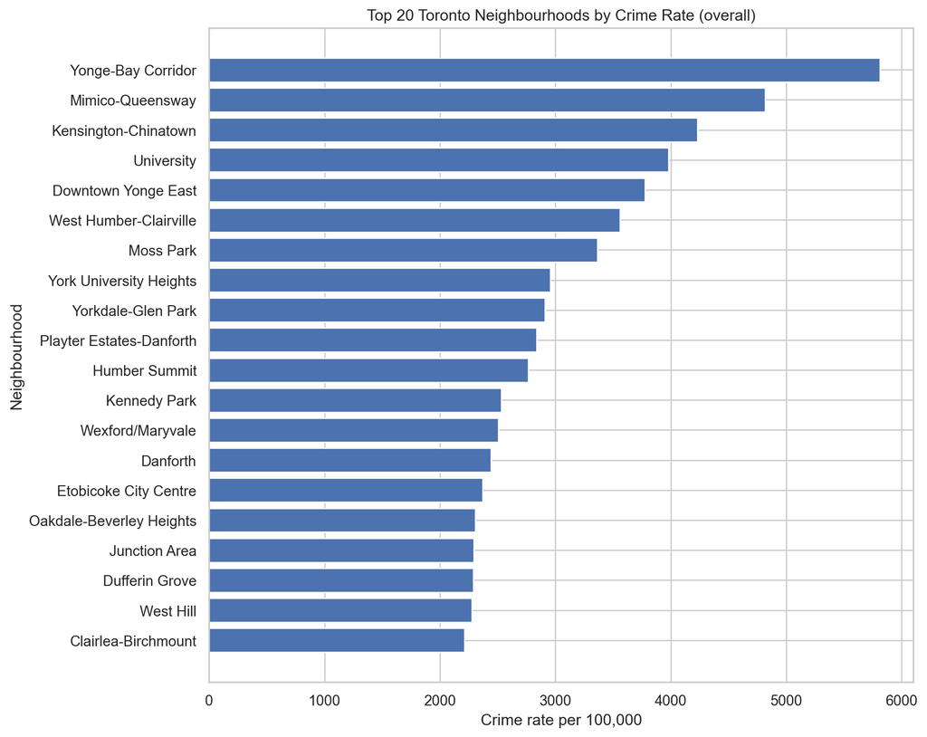

```python
# ranked dot plot of one important rate

overall_rate_col = 'overall_rate_col'

top20 = (
    df[['area_name', overall_rate_col]]
    .sort_values(overall_rate_col, ascending=False)
    .head(20)
    .sort_values(overall_rate_col, ascending=True)
)

plt.figure(figsize=(10, 8))
plt.barh(top20['area_name'], top20[overall_rate_col])
plt.xlabel('Crime rate per 100,000')
plt.ylabel('Neighbourhood')
plt.title('Top 20 Toronto Neighbourhoods by Crime Rate (overall)')
plt.tight_layout()
plt.show()
```

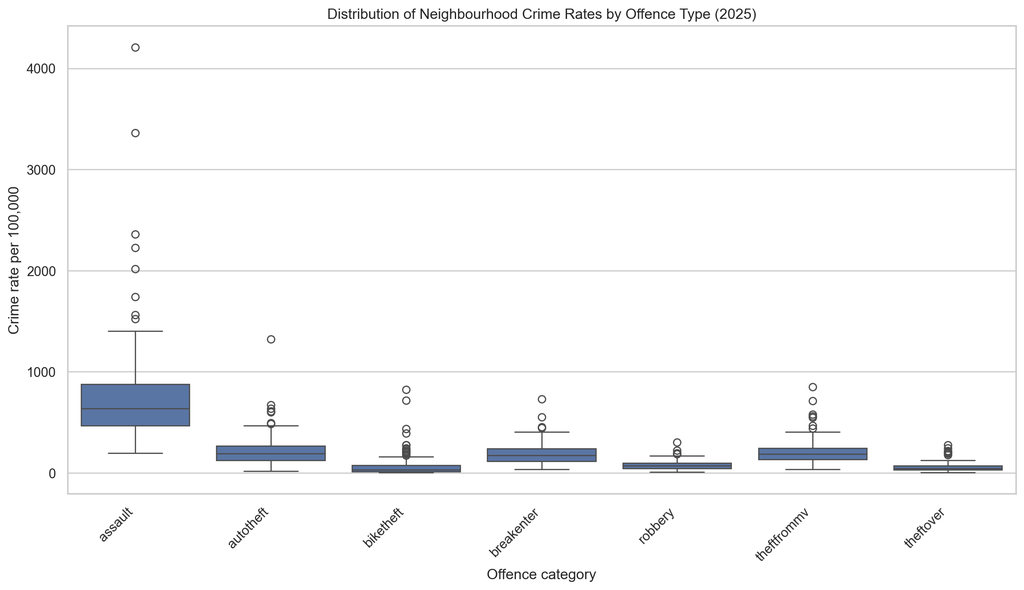

```python
# side-by-side boxplots of offence rates
box_df = df[rate_cols].melt(var_name="offence", value_name="rate")
box_df["offence"] = box_df["offence"].str.replace(f"_rate_{year}", "", regex=False)

plt.figure(figsize=(12, 7))
sns.boxplot(data=box_df, x="offence", y="rate")
plt.xlabel("Offence category")
plt.ylabel("Crime rate per 100,000")
plt.title(f"Distribution of Neighbourhood Crime Rates by Offence Type ({year})")
plt.xticks(rotation=45, ha="right")
plt.tight_layout()
plt.show()
```

- The boxplot above shows that crime rates differ by offence type across neighbourhoods. Assault has the highest typical rate while bike theft and theft over are generally lower.
- It also provide some evidence that answers question 2: Which offence categories show the greatest neighbourhood-to-neighbourhood variation?. From the boxploy, Categories with a wider box, longer whiskers, and more extreme outliers show more variation across neighbourhoods. From this graph, assault appears to have the greatest variation, including alot of extreme outliers and a very wide box, whereas robbery and theftover are lower overall.

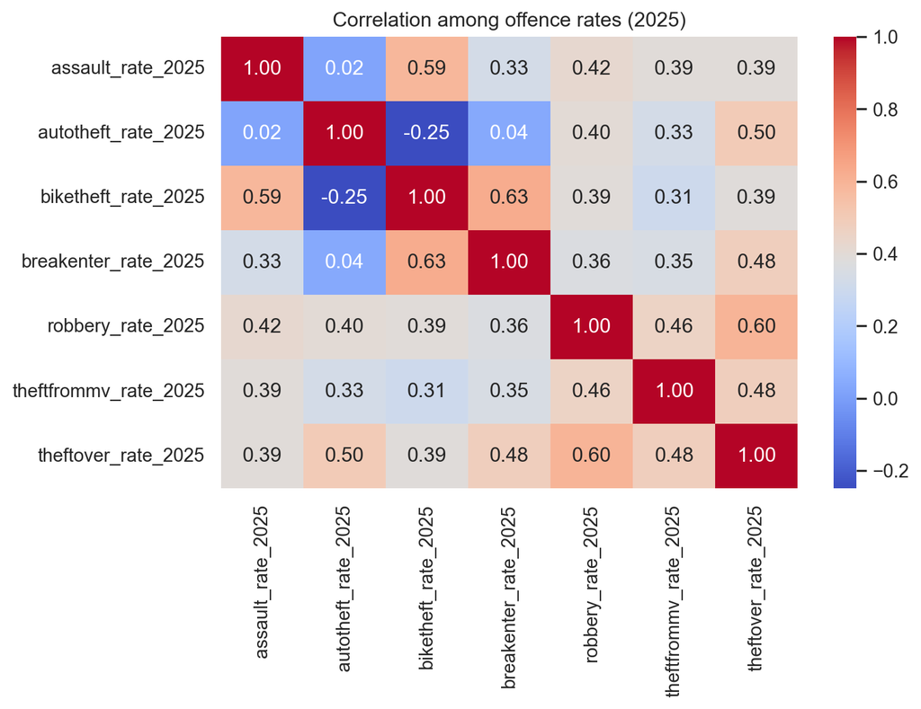

```python
# correlation heatmap of offence rates
heatmap_df = df[[f"{off}_rate_{year}" for off in offences]].copy()

corr = heatmap_df.corr()

plt.figure(figsize=(8, 6))
sns.heatmap(corr, annot=True, cmap="coolwarm", fmt=".2f")
plt.title(f"Correlation among offence rates ({year})")
plt.tight_layout()
plt.show()
```

- The heatmap shows the correlation between these crime type in 2025. We can see most of them are possily correlated, but not strongly. Some of them have strong correlation like breakenter and bike theft.
- This is my first try for answering question 3: ‘Do neighbourhoods with high values in one offence category also tend to have high values in others?’ However, with only correlations, we cannot draw a clear conclusion.

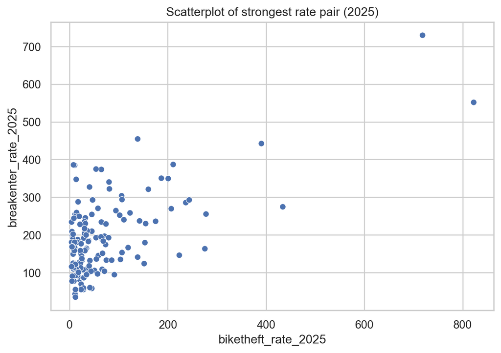

```
Strongest pair: biketheft_rate_2025 and breakenter_rate_2025
Correlation: 0.6278814371302223
```

```python
# scatterplot of the strongest correlated pair
corr_abs = corr.abs().copy()

for i in range(len(corr_abs)):
    corr_abs.iloc[i, i] = 0

best_pair = corr_abs.stack().idxmax()
x_col, y_col = best_pair

plt.figure(figsize=(7, 5))
sns.scatterplot(data=df, x=x_col, y=y_col)
plt.title(f"Scatterplot of strongest rate pair ({year})")
plt.xlabel(x_col)
plt.ylabel(y_col)
plt.tight_layout()
plt.show()

print("Strongest pair:", x_col, "and", y_col)
print("Correlation:", corr.loc[x_col, y_col])
```

- The scatterplot shows the relationship between breakenter and biketheft rates, which are the two with highest correlation. Even we see some likely linear relationship, we cannot guarantee a clear relationship without extra statistical evidence.

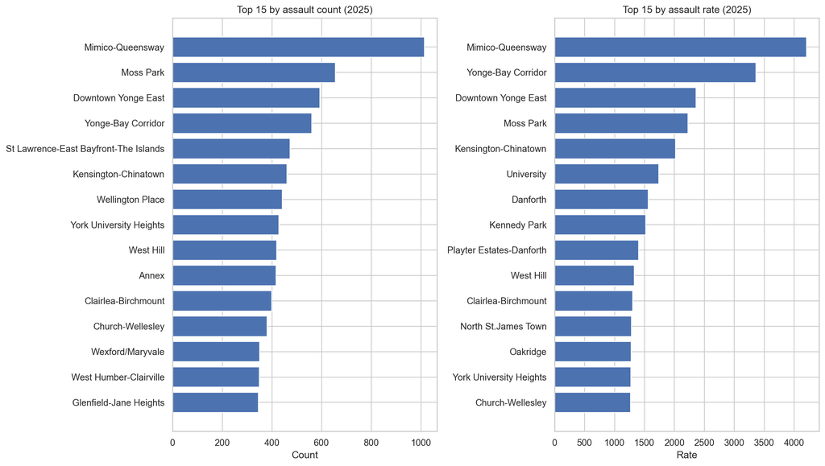

```python
# compare counts and rates for one offence
if "assault" in offences:
    compare_offence = "assault"
else:
    compare_offence = offences[0]

count_col = f"{compare_offence}_{year}"
rate_col = f"{compare_offence}_rate_{year}"

top_n = 15

count_rank = (
    df[[neighbourhood_col, count_col]]
    .dropna()
    .sort_values(by=count_col, ascending=True)
    .tail(top_n)
)

rate_rank = (
    df[[neighbourhood_col, rate_col]]
    .dropna()
    .sort_values(by=rate_col, ascending=True)
    .tail(top_n)
)

fig, axes = plt.subplots(1, 2, figsize=(14, 8))

axes[0].barh(count_rank[neighbourhood_col], count_rank[count_col])
axes[0].set_title(f"Top {top_n} by {compare_offence} count ({year})")
axes[0].set_xlabel("Count")

axes[1].barh(rate_rank[neighbourhood_col], rate_rank[rate_col])
axes[1].set_title(f"Top {top_n} by {compare_offence} rate ({year})")
axes[1].set_xlabel("Rate")

plt.tight_layout()
plt.show()
```

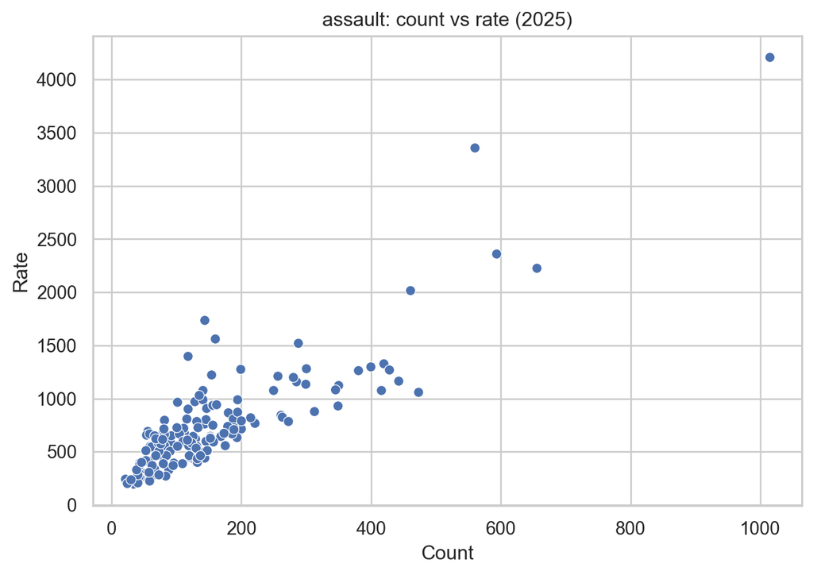

```python
# a simpler count-vs-rate scatterplot
plt.figure(figsize=(7, 5))
sns.scatterplot(data=df, x=count_col, y=rate_col)
plt.title(f"{compare_offence}: count vs rate ({year})")
plt.xlabel("Count")
plt.ylabel("Rate")
plt.tight_layout()
plt.show()
```

- The two bar plots shows a comparsion between crime counts rank and crime rates rank, for a specific categroy, assault. From this we can see that not all of them matches! Moss park has the 2nd highest assault count but 4th highest in assault rate. This suggests that Crime counts and crime rates may not always align, and the population may have a high effect. However, this is only a specific crime in a specific year, and most of them, although dont match in rank, appear on both plots. More statistical evidence is required to answer question 4: ‘Do crime counts and crime rates tell the same story across neighbourhoods?’

## 6. Hypothesis testing

```python
q3_results = []

for col1, col2 in combinations(rate_cols, 2):
    x = np.log1p(df[col1])   # log(1+x)
    y = np.log1p(df[col2])

    r, p = pearsonr(x, y)

    q3_results.append({
        "offence_1": col1.replace(f"_rate_{year}", ""),
        "offence_2": col2.replace(f"_rate_{year}", ""),
        "pearson_r": r,
        "p_value": p
    })

q3_results = pd.DataFrame(q3_results).sort_values("p_value", ascending=False).round(3)
q3_results
```

|  | offence_1 | offence_2 | pearson_r | p_value |
| --- | --- | --- | --- | --- |
| 0 | assault | autotheft | 0.007 | 0.929 |
| 7 | autotheft | breakenter | -0.071 | 0.376 |
| 2 | assault | breakenter | 0.222 | 0.005 |
| 10 | autotheft | theftover | 0.245 | 0.002 |
| 15 | breakenter | robbery | 0.261 | 0.001 |
| 8 | autotheft | robbery | 0.263 | 0.001 |
| 5 | assault | theftover | 0.303 | 0.000 |
| 16 | breakenter | theftfrommv | 0.303 | 0.000 |
| 9 | autotheft | theftfrommv | 0.305 | 0.000 |
| 20 | theftfrommv | theftover | 0.360 | 0.000 |
| 17 | breakenter | theftover | 0.370 | 0.000 |
| 3 | assault | robbery | 0.381 | 0.000 |
| 19 | robbery | theftover | 0.421 | 0.000 |
| 4 | assault | theftfrommv | 0.435 | 0.000 |
| 18 | robbery | theftfrommv | 0.436 | 0.000 |
| 1 | assault | biketheft | NaN | NaN |
| 6 | autotheft | biketheft | NaN | NaN |
| 11 | biketheft | breakenter | NaN | NaN |
| 12 | biketheft | robbery | NaN | NaN |
| 13 | biketheft | theftfrommv | NaN | NaN |
| 14 | biketheft | theftover | NaN | NaN |

## Summary of current findings

- After the above process, some of the questions can be answered with the facts found from the dataset (with tables, visualizations or hypothesis test): the recorded crime rate is very different across different neighborhoods. Moreover, assault shows the greatest neighbourhood-to-neighbourhood variation (Some place has alot, some place has very few). Crimes are somewhat linear related, meaning that having alot of crime in one type often means other kinds are also common. High counts in crime often means high rate, but not guaranteed. Population may make the storytelling of crime count and crime rate different.
- There are also some interesting fact about the dataset per se: quite a lot of missing values (may lead to misleading conclusions), long time coverage (2014-2025), etc.

## Plan for the final project

- I believe with ML and interactive visualization, I should come up with more interesting questions that can be answered with this dataset. Or, I should use more statistical way to prove and support my current conclusions of existing questions.
- 1. First thing to do is to adjust the dataset that works better with model training.
- 2. The dataset covers very long range of time (2014-2025), so I will build a supervised learning models, such as regression and classification. I can use data from previous years to train the model, and use that of the later years to test. It could answer questions like: ‘Can past crime patterns predict whether a neighbourhood will be high-risk next year?’
- 3. I will apply unsupervised learning methods such as clustering and PCA to identify common neighbourhood crime profiles and study whether crime categories tend to occur together.
- 4. I will build an interactive website to present the project. Now the visualizations focus on only 2025. I can make it interactive so the reader can switch between different years and see the difference. Also, I can apply other filters like count/rate filter, or offence categories filter.
- 5. Apply some design. Since we are using website to present information, I will apply some design to make the website looks cooler and more attractive.